# HW 05 - Putting it all together!

# Learning goals

- Apply functions for data importing, recoding, wrangling and visualization
- Working through these exercises with less scaffolding

## Data

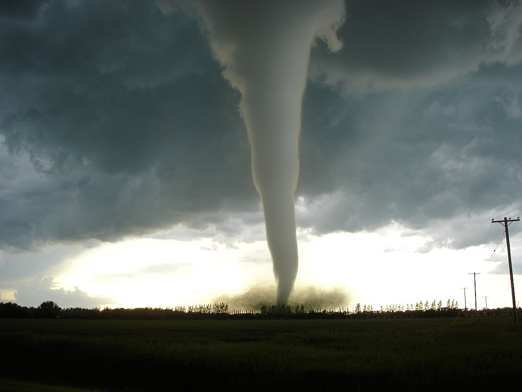

F5 Tornado - Source: Wikipedia

We will be working with data downloaded from the [NOAA Severe Storm Database](https://www.kaggle.com/atinakarim/noaa-severe-storm-database).

In particular, we will use the `tornado-path.csv` data in which each observation (row) represents a tornado that hit the U.S. (and affiliated damages) from 1950 onwards.

## Packages

We will need `dplyr` functions from the tidyverse.

```r
library(tidyverse)
```

## Warm up

Before we introduce the data, let’s warm up with some simple exercises.

- Update the YAML, changing the author name to your name, and **knit** the document.
- Commit your changes with a meaningful commit message.
- Push your changes to GitHub.
- Go to your repo on GitHub and confirm that your changes are visible in your Rmd **and** md files. If anything is missing, commit and push again.

## Importing the data

1. Insert and label a code chunk that reads the tornado data into RStudio, assigns it to a sensible object name and provides a glimpse of the newly created object. State below the code chunk how many rows and variables the data set contains.
2. Insert and label a code chunk that will read the data (as in Exercise 1) and then, using a short pipeline, will select only the variables `storm_date`, `storm_time`, `state_name`, `magnitude`, `fatality_count`, `length`, and `width` from the data frame object you created in Exercise 1. Assign the output of this code such that it **over-writes** the object you created in Exercise 1.
3. Insert and label a code chunk to take a look at the over-written object. Using text narrative, comment under the code chunk on what is strange about the variable `magnitude`. Then add and label a second code chunk that writes the new data file as a `.csv` to the `data/` directory and saves it using the same name you gave the R object.
4. Insert and label a code chunk to read in the new `.csv` file you just wrote out, rather than `tornado_path.csv`. Add to the `read_csv` function to fix `magnitude`. Assign the output to a new object name and add one further line of code to view the new object and confirm the issue with `magnitude` is resolved.
5. Filter the new data object to only include the states “Kansas” and “Oklahoma”, then pipe the output into ggplot to create a multifaceted scatter plot exploring the relationship between time of day (x axis) and fatalities (y axis). The facets should each correspond to a different magnitude value. Different states (`state_name`) and the range of tornado widths (`width`) should be visible with reasonable aesthetic mappings. Improve the clarity of the axes labels using `labs` and pick a theme layer of your choice. Beneath the output, interpret the plots and write a narrative response about the conditions under which tornado fatalities are generally the highest and any caveats to your interpretation.

**Note**: For Exercise 5 you will get credit for every correct line of code, even if your entire plot isn’t perfect or doesn’t plot due to an error. So try to make an attempt at all the steps!

Great work! You just completed an entire homework without any provided code chunks! You are finished with Homework 5! 🧶 ✅ ⬆️ Knit, *commit, and push your changes to GitHub with an appropriate commit message.*